# Análisis de Ingresos y Gastos del Hogar en México: Exploración, Modelado y Evaluación

## Introducción

El análisis de datos socioeconómicos es fundamental para entender las condiciones de vida y distribución del ingreso en una población. En este estudio, se exploran y modelan datos de la Encuesta Nacional de Ingresos y Gastos de los Hogares (ENIGH) 2022 del INEGI, con el objetivo de identificar las variables que más influyen en el ingreso total trimestral (ingTot_tri) de los hogares en México. Se emplean técnicas de limpieza, transformación y análisis de datos para preparar la información y se aplican modelos de Regresión Lineal y K-Nearest Neighbors (KNN) para predecir los ingresos con base en características de las viviendas y del hogar. Finalmente, se evalúa el desempeño de ambos modelos para determinar cuál tiene un mejor ajuste a los datos.

### 1. Importación y Exploración de Datos

Se cargan los archivos de datos que contienen información sobre gastos, ingresos y viviendas. Posteriormente, se realiza una exploración inicial para conocer la cantidad de variables, el número de observaciones y los tipos de datos presentes en cada conjunto.

```python
import pandas as pd
import numpy as np
import matplotlib.pyplot as plt
import seaborn as sns
import statsmodels.api as sm
from sklearn.model_selection import train_test_split
from sklearn.linear_model import LinearRegression
from sklearn.neighbors import KNeighborsRegressor
from sklearn.metrics import mean_squared_error, r2_score
from sklearn.feature_selection import SequentialFeatureSelector


gastos_df = pd.read_csv("conjunto_de_datos_gastoshogar_enigh2022_ns.csv")
ingresos_df = pd.read_csv("conjunto_de_datos_ingresos_enigh2022_ns.csv")
viviendas_df = pd.read_csv("conjunto_de_datos_viviendas_enigh2022_ns.csv")


print(gastos_df.info())
print(ingresos_df.info())
print(viviendas_df.info())
```

[output not shown]

### 2. Preprocesamiento y Limpieza de Datos

Se convierten las columnas relevantes a formato numérico para evitar errores. Se agrupan los ingresos y gastos a nivel de vivienda.

```python
gastos_df["gasto_tri"] = pd.to_numeric(gastos_df["gasto_tri"], errors='coerce')
ingresos_df["ing_tri"] = pd.to_numeric(ingresos_df["ing_tri"], errors='coerce')


gastos_agrupados = gastos_df.groupby("folioviv", as_index=False)["gasto_tri"].sum()
gastos_agrupados.rename(columns={"gasto_tri": "gastoTot_tri"}, inplace=True)

ingresos_agrupados = ingresos_df.groupby("folioviv", as_index=False)["ing_tri"].sum().reset_index()
ingresos_agrupados.rename(columns={"ing_tri": "ingTot_tri"}, inplace=True)
```

### 3. Conversión de Variables Categóricas

Se convierten variables cualitativas en variables dummy para su uso en modelos de regresión.

```python
variables_categoricas = ["tipo_viv", "mat_pared", "mat_techos", "mat_pisos", "disp_agua", "dotac_agua", "excusado", "drenaje", "disp_elect", "combustible", "eli_basura", "tenencia", "tipo_adqui", "viv_usada", "tipo_finan", "tam_loc", "est_socio"]
viviendas_df = pd.get_dummies(viviendas_df, columns=variables_categoricas, drop_first=True)
```

### 4. Integración de Datos

Se fusionan las bases de datos de gastos, ingresos y viviendas.

```python
df_final = pd.merge(gastos_agrupados, ingresos_agrupados, on="folioviv", how="outer")
df_final = pd.merge(df_final, viviendas_df, on="folioviv", how="left")
df_final.fillna(0, inplace=True)
```

### 5. Eliminación de Valores Atípicos

Para mejorar la calidad de los datos y evitar que valores extremos afecten los análisis, se implementa una función que elimina valores atípicos utilizando el método del Rango Intercuartílico (IQR).

```python
def remove_outliers(df):
    numeric_cols = df.select_dtypes(include=[np.number]).columns
    Q1 = df[numeric_cols].quantile(0.25)
    Q3 = df[numeric_cols].quantile(0.75)
    IQR = Q3 - Q1
    k = 3
    lower_bound = Q1 - k * IQR
    upper_bound = Q3 + k * IQR
    return df[~((df[numeric_cols] < lower_bound) | (df[numeric_cols] > upper_bound)).any(axis=1)]

remove_outliers_flag = True
if remove_outliers_flag:
    df_final = remove_outliers(df_final)
```

### 6. Análisis de Correlación

Se genera un heatmap para visualizar la relación entre las variables.

- La diagonal roja indica autocorrelación (correlación = 1).
- Se observan grupos de variables altamente correlacionadas en sectores específicos.
- Variables económicas y de infraestructura muestran relaciones significativas.
- Hay zonas con baja correlación o datos ausentes, sugiriendo revisión de datos.

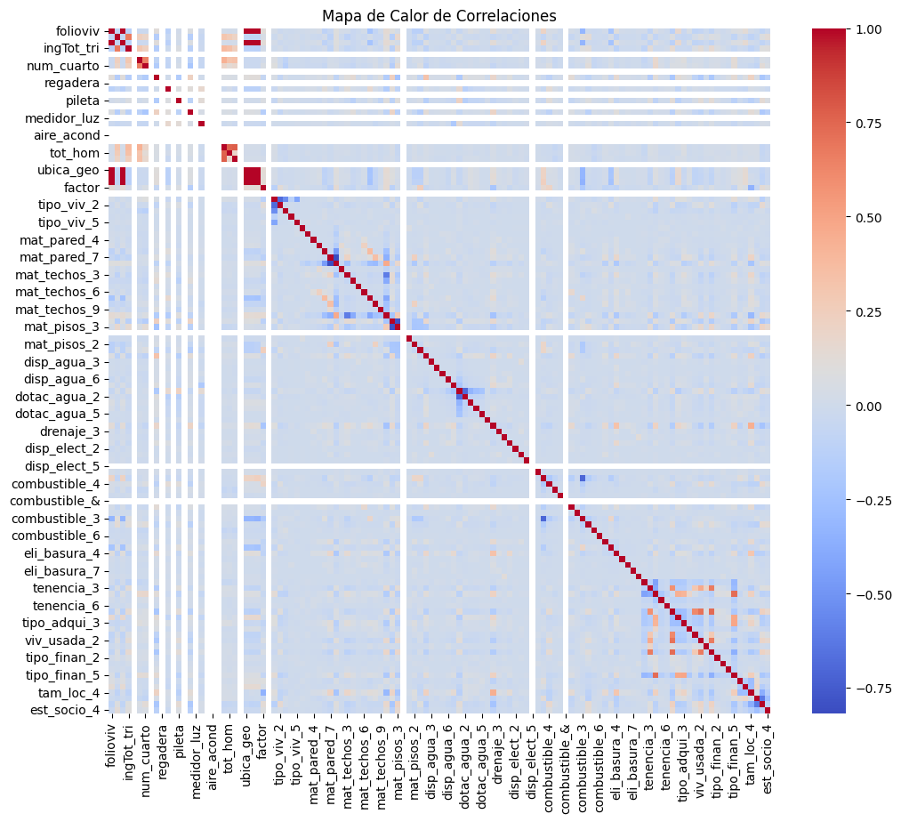

```python
plt.figure(figsize=(12, 10))
sns.heatmap(df_final.corr(numeric_only=True), annot=False, cmap='coolwarm', fmt=".2f")
plt.title("Mapa de Calor de Correlaciones")
plt.show()
```

### 7. Selección de Características

Se aplicó una selección de características para identificar las variables más relevantes en la predicción del ingreso total trimestral (ingTot_tri). Se eliminaron columnas irrelevantes y se filtraron solo las variables numéricas sin valores nulos. Luego, con un modelo de regresión lineal y un Selector de Características Secuencial (SFS) en dirección hacia adelante, se seleccionaron las cinco variables más significativas: gastoTot_tri, cuart_dorm, fregadero, tot_resid y upm. Esto permite reducir la dimensionalidad del modelo, mejorar su eficiencia y evitar información redundante.

```python
X = df_final.drop(columns=["ingTot_tri", "folioviv"])
y = df_final["ingTot_tri"]
X = X.select_dtypes(include=[np.number]).dropna()
y = y[X.index]

lin_reg = LinearRegression()
sfs = SequentialFeatureSelector(lin_reg, n_features_to_select=5, direction='forward')
sfs.fit(X, y)
selected_features = X.columns[sfs.get_support()]
print("Características seleccionadas:", selected_features)
X = X[selected_features]
```

```
Características seleccionadas: Index(['gastoTot_tri', 'cuart_dorm', 'fregadero', 'tot_resid', 'upm'], dtype='object')
```

### 8. División de Datos

Se divide el conjunto de datos en entrenamiento (70%) y prueba (30%).

```python
X_train, X_test, y_train, y_test = train_test_split(X, y, test_size=0.3, random_state=666)
```

### 9. Modelado y Evaluación

Se entrenaron y evaluaron dos modelos de regresión: Regresión Lineal y K-Nearest Neighbors (KNN) con k=5. Ambos modelos fueron ajustados utilizando los datos de entrenamiento y posteriormente se realizaron predicciones sobre el conjunto de prueba. Para evaluar su desempeño, se calcularon el Error Cuadrático Medio (MSE) y el coeficiente de determinación (R²).

```python
lin_reg.fit(X_train, y_train)
y_pred_lin = lin_reg.predict(X_test)

knn_reg = KNeighborsRegressor(n_neighbors=5)
knn_reg.fit(X_train, y_train)
y_pred_knn = knn_reg.predict(X_test)

mse_lin = mean_squared_error(y_test, y_pred_lin)
r2_lin = r2_score(y_test, y_pred_lin)
mse_knn = mean_squared_error(y_test, y_pred_knn)
r2_knn = r2_score(y_test, y_pred_knn)
print("Regresión Lineal - MSE:", mse_lin, " R2:", r2_lin)
print("Regresión KNN - MSE:", mse_knn, " R2:", r2_knn)
```

```
Regresión Lineal - MSE: 503017059.17531496  R2: 0.5040999623699085
Regresión KNN - MSE: 641196323.0118303  R2: 0.3678757511104169
```

### 10. Inferencia y Visualización

En esta parte del análisis, se realizó una evaluación de los coeficientes del modelo de Regresión Lineal y se comparó su desempeño con el modelo KNN a través de una visualización gráfica. Se utilizó el método de Mínimos Cuadrados Ordinarios (OLS) para entender cómo las variables influyen en el ingreso total trimestral (ingTot_tri). El análisis de los coeficientes muestra que gastoTot_tri tiene una relación positiva fuerte con la variable objetivo, mientras que cuart_dorm y tot_resid también tienen un impacto positivo. En cambio, fregadero y upm tienen coeficientes negativos, lo que sugiere que afectan de manera inversa al ingreso. El valor de R² = 0.496 indica que el modelo puede explicar aproximadamente el 49.6% de la variabilidad en los datos, lo que sugiere un ajuste moderado.

Para comparar los modelos, se generó un gráfico de dispersión donde los puntos en gris representan los valores reales, mientras que los puntos en azul y verde corresponden a las predicciones de Regresión Lineal y KNN, respectivamente. En la gráfica, se puede notar que la regresión lineal se ajusta mejor a los valores reales en comparación con KNN, ya que este último muestra una mayor dispersión. Esto significa que el modelo de regresión lineal tiene mejor precisión global, mientras que KNN parece menos estable en sus predicciones.

```
                            OLS Regression Results
==============================================================================
Dep. Variable:             ingTot_tri   R-squared:                       0.496
Model:                            OLS   Adj. R-squared:                  0.496
Method:                 Least Squares   F-statistic:                     2219.
Date:                Mon, 24 Feb 2025   Prob (F-statistic):               0.00
Time:                        19:48:50   Log-Likelihood:            -1.2888e+05
No. Observations:               11283   AIC:                         2.578e+05
Df Residuals:                   11277   BIC:                         2.578e+05
Df Model:                           5
Covariance Type:            nonrobust
================================================================================
                   coef    std err          t      P>|t|      [0.025      0.975]
--------------------------------------------------------------------------------
const         7751.1415    954.274      8.123      0.000    5880.598    9621.685
gastoTot_tri     0.9847      0.012     81.573      0.000       0.961       1.008
cuart_dorm    3097.2175    273.058     11.343      0.000    2561.977    3632.458
fregadero    -4230.2243    477.652     -8.856      0.000   -5166.505   -3293.944
tot_resid     3104.9548    143.306     21.667      0.000    2824.051    3385.859
upm             -0.6531      0.073     -8.990      0.000      -0.795      -0.511
==============================================================================
Omnibus:                     2975.306   Durbin-Watson:                   1.978
Prob(Omnibus):                  0.000   Jarque-Bera (JB):            11366.354
Skew:                           1.274   Prob(JB):                         0.00
Kurtosis:                       7.205   Cond. No.                     1.75e+05
==============================================================================

Notes:
[1] Standard Errors assume that the covariance matrix of the errors is correctly specified.
[2] The condition number is large, 1.75e+05. This might indicate that there are
strong multicollinearity or other numerical problems.
```

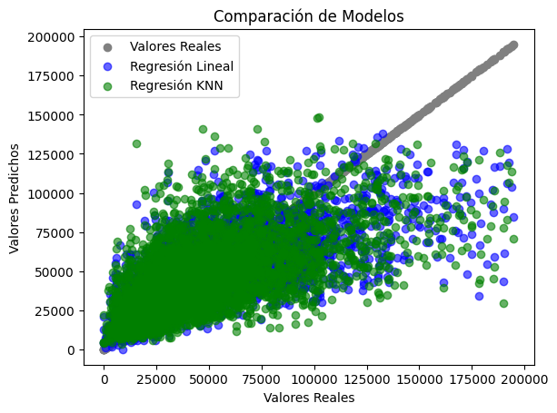

```python
X_train_sm = sm.add_constant(X_train)
model_ols_lin = sm.OLS(y_train, X_train_sm).fit()
print(model_ols_lin.summary())

plt.scatter(y_test, y_test, color='gray', label='Valores Reales')
plt.scatter(y_test, y_pred_lin, color='blue', label='Regresión Lineal', alpha=0.6)
plt.scatter(y_test, y_pred_knn, color='green', label='Regresión KNN', alpha=0.6)
plt.xlabel("Valores Reales")
plt.ylabel("Valores Predichos")
plt.title("Comparación de Modelos")
plt.legend()
plt.show()
```

## Conclusión

A lo largo del análisis, se realizaron diversas etapas de preprocesamiento, selección de características y modelado. Se encontró que las variables gastoTot_tri, cuart_dorm y tot_resid tienen una influencia positiva en el ingreso total trimestral de los hogares, mientras que fregadero y upm mostraron una relación inversa. Al evaluar el desempeño de los modelos, se observó que la Regresión Lineal obtuvo un R² de 0.50, explicando el 50% de la variabilidad en los ingresos, mientras que el modelo KNN mostró un peor desempeño con un R² de 0.37, lo que sugiere que la regresión lineal es más adecuada para este tipo de datos. Además, la visualización de las predicciones confirmó que la Regresión Lineal tiene un mejor ajuste global, mientras que KNN muestra mayor dispersión en sus estimaciones.

Este estudio demuestra la importancia de la exploración y transformación de datos para mejorar la precisión de los modelos predictivos. Como trabajo futuro, se podrían probar otros algoritmos más avanzados, como árboles de decisión o redes neuronales, para mejorar la predicción del ingreso de los hogares en México.

## Referencias

- INEGI (2022). Encuesta Nacional de Ingresos y Gastos de los Hogares (ENIGH) 2022. Disponible en: https://www.inegi.org.mx/app/descarga/ficha.html?tit=1626216&ag=0&f=csv
- ChatGPT (2025). Análisis y Modelado de Datos en Python. Generado con inteligencia artificial por OpenAI.